# Robustness, generalization and reliability

Computer-Aided Medical Diagnostics, MPA-PRM (from 2027/28 Applied AI in Life Sciences, MPA-AUI)

Jiří Chmelík

Department of Biomedical Engineering · FEEC, Brno University of Technology

2026-10-12

## Learning goals

Break a model on purpose

Noise, blur, a darker scanner, three other hospitals — which of them does your model survive, and what does augmentation buy?

Check what 70 % means

Read a reliability diagram, compute ECE and the Brier score, and fix the probabilities with **one** parameter — or two, when the population changes.

Let the model say “I don’t know”

Ensembles, conformal sets, referral to a clinician — and test whether they notice a shift before you trust them.

Notice drift before the accuracy does

Watch a deployed model week by week: PSI, the Kolmogorov–Smirnov test and a count of empty fields.

ECE — expected calibration error · PSI — population stability index

## 1 · When the data change

> A model is validated on the data it was built from. Deployment sends it everything else.

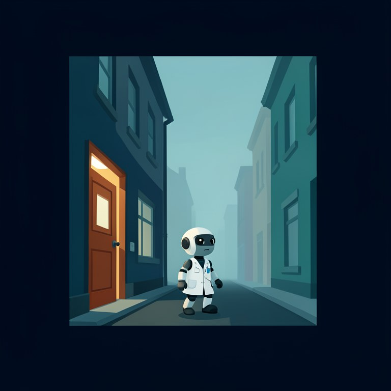

Illustrative image, generated with FLUX.2 [klein] 4B

## The two models you already built

Heart Disease · XGBoost

303 patients, 13 clinical features, disease yes/no. Explained per patient with SHAP, audited for fairness across sex.

PneumoniaMNIST · ResNet18

28 × 28 chest X-rays of children, normal vs. pneumonia. We saw **where** it looks with Grad-CAM.

Both were evaluated **once**, on **one** held-out set. What happens when the data they see start to change?

XGBoost — eXtreme Gradient Boosting · SHAP — SHapley Additive exPlanations · ResNet18 — residual network, 18 layers · Grad-CAM — gradient-weighted class activation mapping

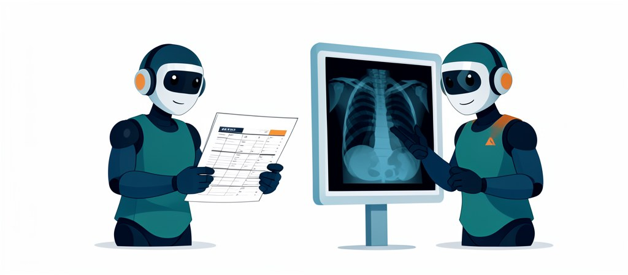

Illustrative image, generated with FLUX.2 [klein] 4B

## Five ways the data can change

Noise

random corruption of the input — detector noise, compression, motion blur

Adversarial

a small, deliberately crafted perturbation that flips the answer

Covariate shift

$P(\mathbf x)$ changes, $P(y \mid \mathbf x)$ does not — a new scanner, a new hospital

Label shift

$P(y)$ changes — a different prevalence of the disease

Concept drift

$P(y \mid \mathbf x)$ itself changes — a new variant, a new diagnostic criterion

[figure not shown]

Illustrative image, generated with FLUX.2 [klein] 4B

## A different hospital

- CNNs for pneumonia on chest X-rays from **three US hospital systems** (NIH, MSH, IU).
- Tested outside the training site: AUC **lower in all five** comparisons, significantly in three.
- The CNN told the hospital system apart in **99.95 %** of the NIH images — and pneumonia was in 34 % of MSH images but 1.2 % of NIH ones.

Zech, Badgeley, Liu, Costa, Titano, Oermann (2018), *PLOS Medicine*, [doi:10.1371/journal.pmed.1002683](https://journals.plos.org/plosmedicine/article?id=10.1371%2Fjournal.pmed.1002683)

CNN — convolutional neural network · NIH — National Institutes of Health Clinical Center · MSH — Mount Sinai Hospital · IU — Indiana University Network for Patient Care

[figure not shown]

## How could it learn “hospital”?

The model never saw a “hospital” feature.  
How could it use the hospital as a shortcut?

Think for a minute, then tell your neighbour.

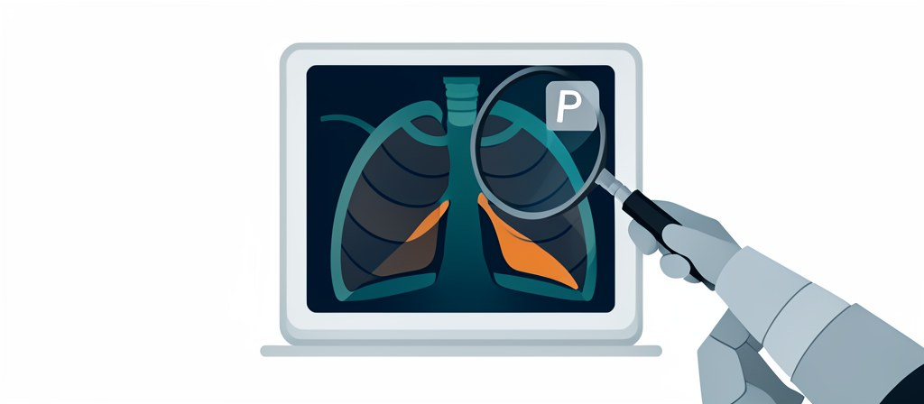

Illustrative image, generated with FLUX.2 [klein] 4B

## Shortcuts in clinical images

COVID-19 on chest X-rays

Models that looked excellent on their own data leaned on **text markers, the image borders and patient positioning** — what the source data set looked like, not the lungs — and did worse in new hospitals.

Melanoma and the surgeon’s pen

A certified dermoscopy CNN on 130 lesions: with gentian-violet **ink marks** around benign nevi its specificity fell from **84.1 % to 45.8 %**; with the marks cropped out it was 97.2 %.

Pneumothorax and the chest drain

AUC **0.94** on pneumothoraces with a chest drain, **0.77** without one. The drain is the treatment — the model is best on the patients who no longer need it.

DeGrave, Janizek, Lee (2021), *Nat Mach Intell* 3:610, [doi:10.1038/s42256-021-00338-7](https://doi.org/10.1038/s42256-021-00338-7) · Winkler et al. (2019), *JAMA Dermatol* 155:1135, [doi:10.1001/jamadermatol.2019.1735](https://doi.org/10.1001/jamadermatol.2019.1735) · Oakden-Rayner, Dunnmon, Carneiro, Ré (2020), [arXiv:1909.12475](https://arxiv.org/abs/1909.12475)

AUC — area under the ROC (receiver operating characteristic) curve

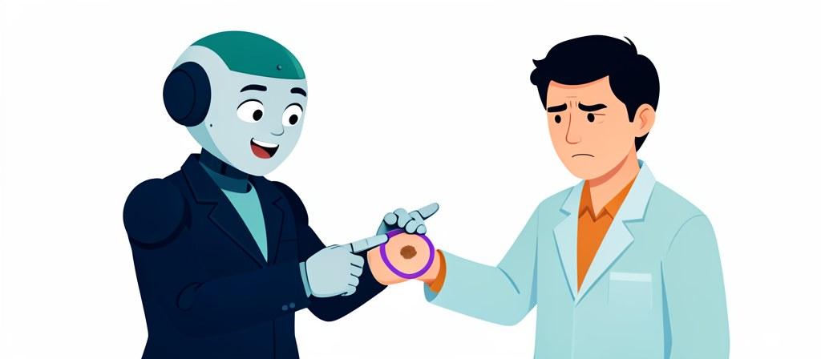

Illustrative image, generated with FLUX.2 [klein] 4B

## Four hospitals, one data set

[figure not shown]

Our data come from **four hospitals** (1988); so far we used only Cleveland. Trained there, the **ranking** degrades a little elsewhere (AUC 0.87 → 0.69–0.83), the **decisions** a lot where more patients are sick (accuracy 0.78 → 0.58).

Janosi, Steinbrunn, Pfisterer, Detrano (1988), UCI Heart Disease, CC BY 4.0, [doi:10.24432/C52P4X](https://doi.org/10.24432/C52P4X) — Cleveland Clinic, Hungarian Institute of Cardiology (Budapest), University Hospitals of Zürich and Basel, VA Medical Center Long Beach

UCI — University of California, Irvine (the machine-learning repository) · VA — US Department of Veterans Affairs

## What the other hospitals did not record

[figure not shown]

- Switzerland recorded **every cholesterol as 0** — not measured, not a result. Taken at face value, the model would read it as a value.
- The deployed pipeline fills a gap with the **Cleveland median** — 165 of 200 VA patients thus enter the model with **no diseased vessel and a normal thallium test**, results nobody measured.

BP — blood pressure · ECG — electrocardiogram · ST — the ST segment of the ECG · ca — number of major vessels coloured by fluoroscopy

## Random, temporal, external

[figure not shown]

Pool the four hospitals and split at random: **AUC 0.87, accuracy 0.80**. Leave each hospital out in turn: **0.76 and 0.69** on average. The random split partly ranks *hospitals* — it learns that Swiss records, recognisable by their empty fields, are mostly sick (accuracy 0.88 vs. 0.63). A **temporal** split (train on earlier patients, test on later ones) asks the drift question instead.

## Split by patient, not by image

- A patient often contributes **many images** — slices of a scan, repeated X-rays, both eyes, tiles of one slide.
- Split the images at random and the same patient sits in training **and** test: the model is tested on someone it has already seen.
- Brain MRI, 2D CNNs, slices split at random instead of by subject: accuracy inflated by **29–55 %** on four data sets; **randomly labelled** data reached **96 %** instead of 50 %.

Your test accuracy is 96 %. Which column of your table says which patient each image came from?

Yagis et al. (2021), *Sci Rep* 11:22544, [doi:10.1038/s41598-021-01681-w](https://doi.org/10.1038/s41598-021-01681-w)

MRI — magnetic resonance imaging · 2D — two-dimensional

## When a deployed model met the real clinic

A sepsis alert in 38 455 admissions

A proprietary sepsis model used in hundreds of US hospitals, validated externally at Michigan Medicine: **AUC 0.63**; at its alert threshold it caught **33 %** of the sepsis cases while alerting on **18 %** of all admitted patients.

Retinal screening in eleven Thai clinics

A diabetic-retinopathy model with high accuracy in its validation studies. In the clinics: dim rooms, slow internet, photographs **rejected as ungradable** — and patients told to travel to a hospital for another examination.

Wong et al. (2021), *JAMA Intern Med* 181:1065, [doi:10.1001/jamainternmed.2021.2626](https://doi.org/10.1001/jamainternmed.2021.2626) · Beede et al. (2020), *CHI ’20*, [doi:10.1145/3313831.3376718](https://doi.org/10.1145/3313831.3376718)

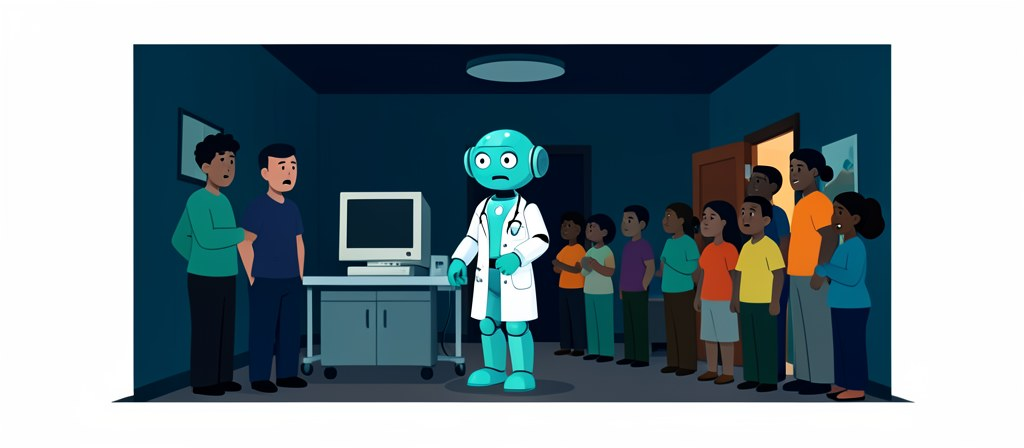

Illustrative image, generated with FLUX.2 [klein] 4B

## What makes a model more robust

Augmentation

train on noisy, blurred, darker versions, so the variation is seen before deployment

Domain adaptation

align the features of the source and the target hospital

Ensembling

average several models — their independent errors partly cancel

Adversarial training

train on worst-case perturbations, not just natural noise

A benchmark for medical images: MedMNIST-C, 12 corruptions at 5 severities ([arXiv:2406.17536](https://arxiv.org/abs/2406.17536)) — the same idea as ImageNet-C.

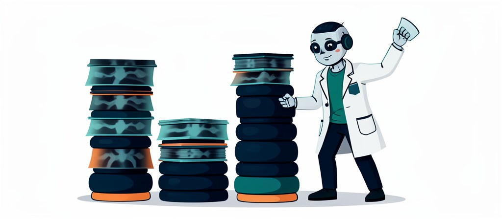

Illustrative image, generated with FLUX.2 [klein] 4B

## Four corruptions, five severities

[figure not shown]

## Accuracy under corruption

[figure not shown]

- Clean: **0.885** on the 200 X-rays.
- Noise costs little until severity 4.
- A **35 % darker** image (severity 3): **0.665**; 48 % darker or 32 % contrast (severity 4): the model answers “pneumonia” for everything — **0.66**.
- It never saw a change of intensity in training.

The dangerous corruption is not the one that looks worst — it is the one the training data never contained. That is what augmentation is for.

## Augmentation, measured

[figure not shown]

Same network, same images, one change: every training X-ray got a random brightness (×0.4–1) and contrast (×0.2–1). A 35 % darker image: **0.665 → 0.875**. The price: clean accuracy **0.885 → 0.790** — with the same ranking (AUC 0.971 vs 0.973 on all 624).

## Augmentation — strengths and pitfalls

Use it when

- You know **which variation** deployment will bring: scanners, exposure, positioning, compression.
- It costs no new data and no new labels — only training time.
- On our model it turned a collapse to 0.66 into 0.88 at 35 % darker.

Watch out

- It covers **what you put in**: noise and blur did not improve, and brightness fell again at the edge of the jitter range (×0.4).
- It can **shift the threshold**: clean accuracy 0.885 → 0.790 with the same AUC.
- A transformation that changes the diagnosis (a flip of a lateralized finding, a crop that removes the lesion) teaches the wrong label.

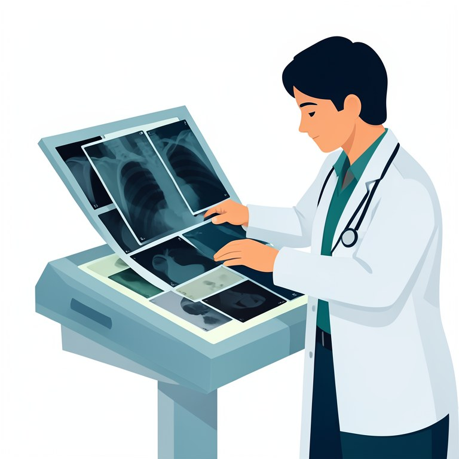

Illustrative image, generated with FLUX.2 [klein] 4B

## An invisible change that flips the answer

[figure not shown]

Ten small steps that increase the loss of the true label, each kept within $\varepsilon$ of the original (projected gradient descent, PGD):

$$\mathbf x_{k+1} = \operatorname{clip}_{\mathbf x,\varepsilon}\big(\mathbf x_k + \tfrac{\varepsilon}{4}\operatorname{sign}\nabla_{\mathbf x} L\big)$$

$\varepsilon = 0.008$: at most 2 of 255 grey levels per pixel.

One step of size $\varepsilon$ is FGSM (fast gradient sign method) — Goodfellow, Shlens, Szegedy (2015), [arXiv:1412.6572](https://arxiv.org/abs/1412.6572); the iterated, projected version — Madry et al. (2018), [arXiv:1706.06083](https://arxiv.org/abs/1706.06083)

## 2 · Can you trust 70 %?

> Softmax gives you a number between 0 and 1. Nobody promised it is a probability.

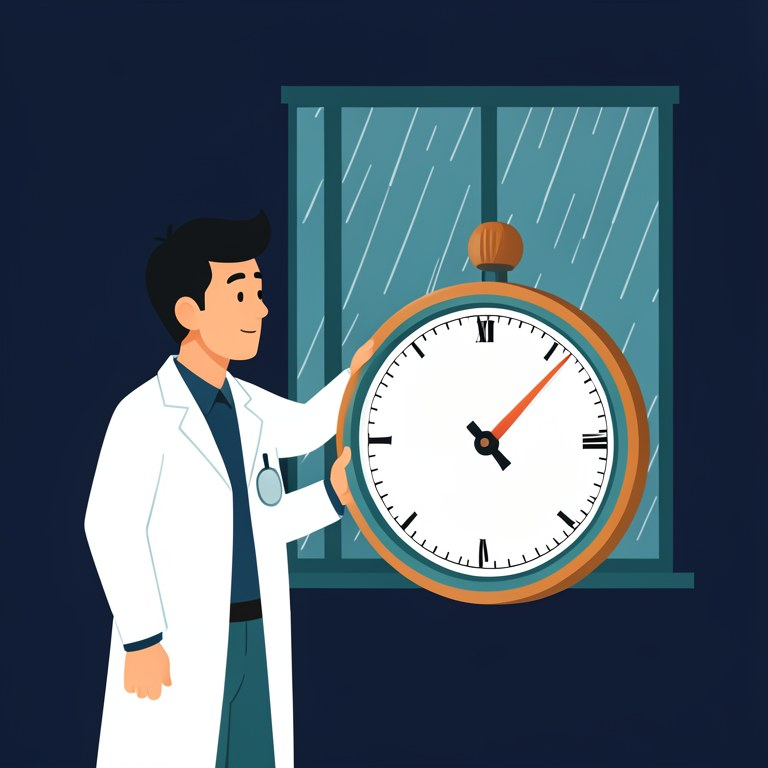

Illustrative image, generated with FLUX.2 [klein] 4B

## The probability you already use

- Logistic regression, softmax, Gaussian mixtures — from *Machine Learning and Recognition* you know models that output a number between 0 and 1.
- A clinician reads it as a **risk**: 70 % means operate, 20 % means wait.

Out of 100 patients the model scores at 70 %, do about **70** have the disease?

If yes, the model is **calibrated**. Accuracy does not tell you — a model can rank patients perfectly and still be wrong about every probability.

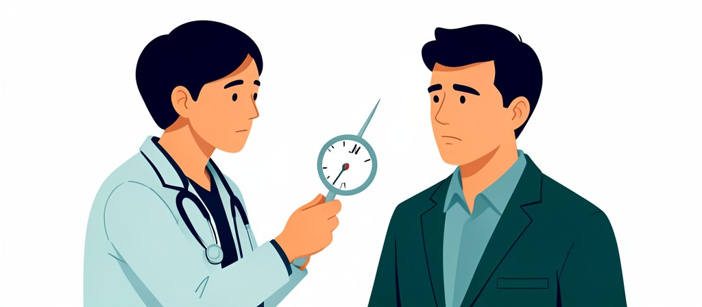

Illustrative image, generated with FLUX.2 [klein] 4B

## Reliability diagrams

- Sort the predictions into **bins** by predicted probability.
- In every bin compare the **mean predicted probability** with the **observed frequency** of the disease.
- Calibrated: every bin on the diagonal.
- Modern, over-parameterized networks are often **overconfident** — bars below the diagonal.

[figure not shown]

Guo, Pleiss, Sun, Weinberger (2017), *On Calibration of Modern Neural Networks*, [arXiv:1706.04599](https://arxiv.org/abs/1706.04599)

## ECE and the Brier score

$$\mathrm{ECE} = \sum_{m=1}^{M} \frac{|B_m|}{n}\,\big|\,\mathrm{freq}(B_m) - \mathrm{conf}(B_m)\,\big|
\qquad
\mathrm{BS} = \frac{1}{n}\sum_{i=1}^{n} (p_i - y_i)^2$$

- $B_m$ is the $m$-th bin, $\mathrm{freq}(B_m)$ the observed frequency of the disease in it, $\mathrm{conf}(B_m)$ the mean predicted probability; ECE is the gap per bin, weighted by the bin’s share of patients.
- $p_i$ is the predicted probability, $y_i \in \{0, 1\}$ the outcome; the Brier score is the mean squared error of the probabilities — lower is better, and it rewards calibration *and* sharpness.

**A worked bin:** 100 of $n$ patients scored about 0.80, and 65 of them are sick. The bin adds $\frac{100}{n}\cdot|0.65 - 0.80| = \frac{100}{n}\cdot 0.15$ to ECE — a 15-point overconfidence gap.

## Temperature scaling

**logit** $z$

the model’s raw score

→

**divide by** $T$

one parameter

→

**sigmoid**

$\hat p = \sigma(z / T)$

- $T$ is fitted **after** training, by minimizing the negative log-likelihood on a **held-out calibration split** — never on the test set.
- $T > 1$ softens overconfident probabilities, $T < 1$ sharpens underconfident ones.
- The order of the patients does not change, so neither do accuracy nor AUC.

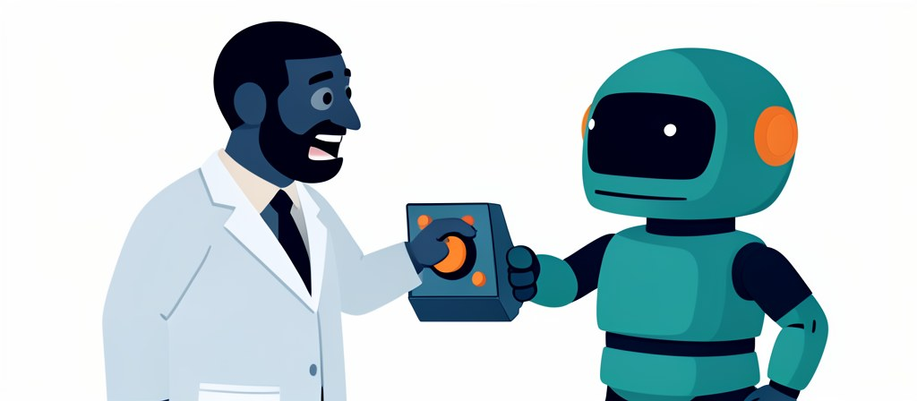

Illustrative image, generated with FLUX.2 [klein] 4B

## Calibrating the Heart Disease model

[figure not shown]

Split 50 / 25 / 25 % (151 / 76 / 76 patients); $T = 1.80$ fitted on the calibration part, the diagrams on the test part. Accuracy 0.842 before and after.

## One split is not enough

[figure not shown]

Twenty random splits, the whole procedure repeated: temperature scaling helps in 18 of 20 by ECE and 19 of 20 by the Brier score. One split of 76 patients could have told you either story.

## Calibration does not travel

[figure not shown]

The fix is local and cheap: keep the model, re-fit **one** number, the intercept $b$ in $\hat p = \sigma(z/T + b)$, on a few labelled patients of the new hospital. It repairs the probabilities, not the ranking.

## Calibrating the ResNet18

[figure not shown]

On the validation split the network is right 97 % of the time and $T = 1.08$ — “calibrated”. On the test X-rays it is right 86 % of the time and calls pneumonia too often. A temperature cannot fix that; the intercept can: over 20 splits ECE **0.143 → 0.032**, accuracy at 0.5 **0.855 → 0.930**.

## Temperature scaling — strengths and pitfalls

Use it when

- A trained model is **overconfident or underconfident** and you cannot or do not want to retrain it.
- One parameter: it needs only a modest **calibration split** and cannot overfit much.
- The ranking and every decision at 0.5 stay as they were — accuracy and AUC unchanged.

Watch out

- It fixes **one** kind of miscalibration: too sharp or too flat. A shifted average needs the intercept.
- Fitted on one population, it **does not travel**: Switzerland 0.40 ECE with the Cleveland $T$.
- On 76 test patients its effect is within the noise of one split — measure it over many.
- Fitted on the test set, it is a leak.

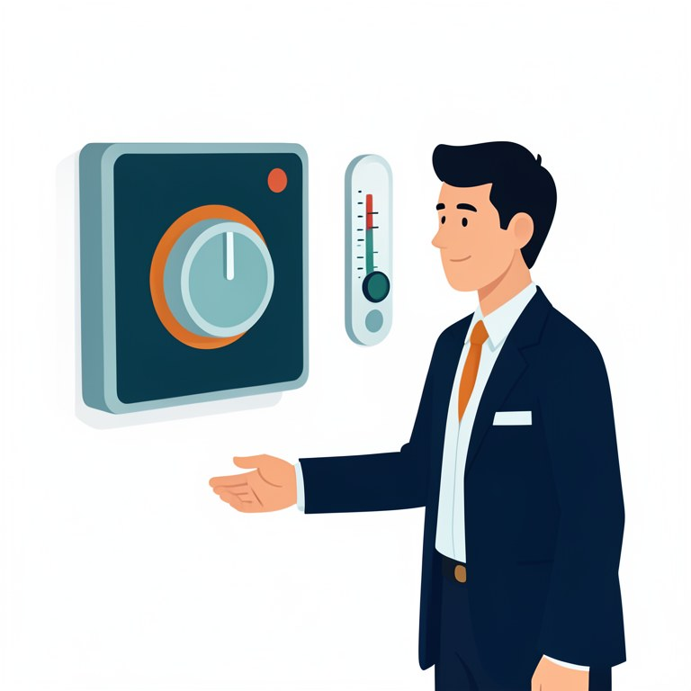

Illustrative image, generated with FLUX.2 [klein] 4B

## 3 · Knowing what you don’t know

> A confident wrong answer is worse than an honest “I don’t know”.

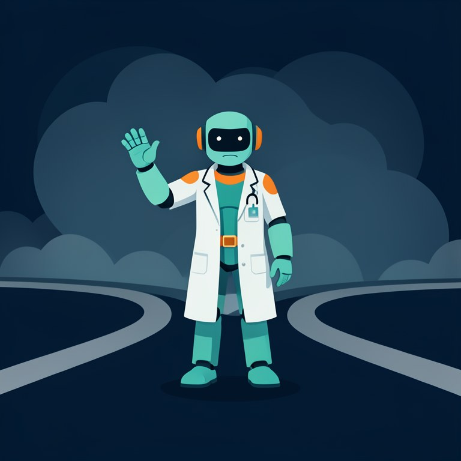

Illustrative image, generated with FLUX.2 [klein] 4B

## Three ways to estimate uncertainty

| method | how | cost and guarantee |
| --- | --- | --- |
| **MC Dropout** | keep dropout on at prediction time, average $S$ stochastic passes | one model, cheap; no guarantee |
| **Deep ensemble** | train several models from different seeds, look at their disagreement | $N$ trainings; no guarantee, but works well in practice |
| **Conformal prediction** | wrap any model’s output into a calibrated **prediction set** | one calibration pass; a finite-sample guarantee |

Gal, Ghahramani (2016), [arXiv:1506.02142](https://arxiv.org/abs/1506.02142) · Lakshminarayanan, Pritzel, Blundell (2017), [arXiv:1612.01474](https://arxiv.org/abs/1612.01474) · Angelopoulos, Bates (2021), [arXiv:2107.07511](https://arxiv.org/abs/2107.07511)

MC — Monte Carlo (the $S$ random passes)

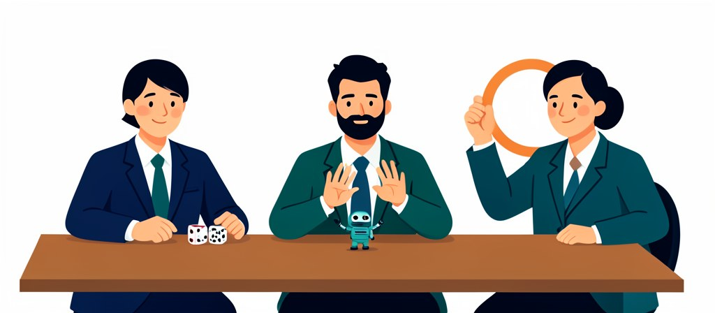

Illustrative image, generated with FLUX.2 [klein] 4B

## Not every uncertainty knows where the data end

[figure not shown]

Mean standard deviation of the predictions — MC Dropout: 0.18 inside the training range, 0.11 outside. Ensemble: 0.016 inside, 0.47 outside.

## Two kinds of uncertainty

Aleatoric — in the data

Noise and ambiguity that **no model can remove**: a blurred X-ray, a borderline lesion, two readers who disagree. On the sine it is the noise we added, standard deviation 0.15 — inside the data and outside alike. More data do not shrink it.

Epistemic — in the model

What the model **does not know** because it has not seen enough: far from the training data, a rare subgroup, a new scanner. The ensemble’s spread: 0.016 inside the sine’s range, 0.47 outside. More data of the right kind shrink it.

An OOD flag needs the **epistemic** part. A spread that mixes both — or measures neither, like the dropout noise on the sine — does not grow where the data end.

OOD — out of distribution: an input unlike the data the model was trained on

## The mean and the spread of repeated predictions

$$\hat y(\mathbf x) = \frac{1}{S}\sum_{s=1}^{S} f_s(\mathbf x)
\qquad
\widehat{\operatorname{Var}}\,[\,y \mid \mathbf x\,] = \frac{1}{S}\sum_{s=1}^{S} f_s(\mathbf x)^2 - \hat y(\mathbf x)^2$$

- $f_s(\mathbf x)$ is the $s$-th prediction for the input $\mathbf x$: one pass with a fresh dropout mask, or one member of an ensemble.
- The prediction is their mean, the uncertainty their variance.

**Five predictions for one X-ray:** $0.71, 0.68, 0.74, 0.69, 0.73$ — mean $0.71$, variance $0.0005$: they agree. $0.20, 0.95, 0.90, 0.60, 0.90$ — the same mean $0.71$, variance $0.080$: the model is guessing.

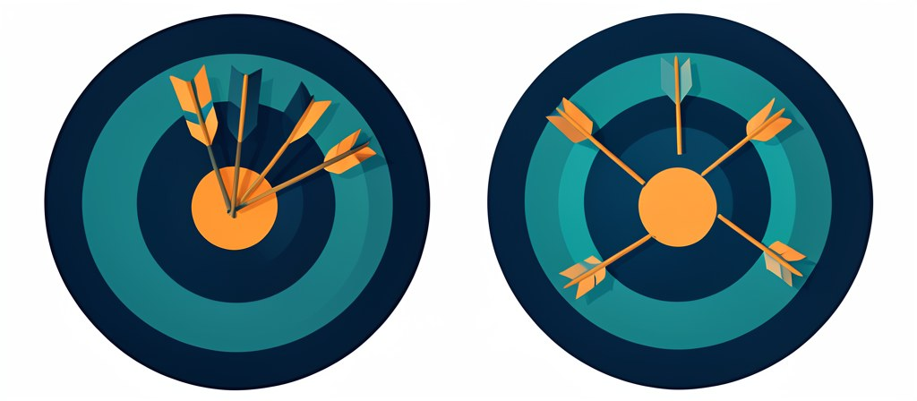

Illustrative image, generated with FLUX.2 [klein] 4B

## MC Dropout — strengths and pitfalls

Use it when

- The network **already has dropout**: no retraining, only $S$ forward passes at prediction time.
- You need a cheap, rough “how stable is this answer” for one input.
- One model to store, validate and deploy.

Watch out

- Much of the spread is the **noise of dropping units**, not ignorance: on the sine it was 0.18 inside the data and 0.11 outside.
- It can be **confidently wrong** far from the data — exactly where a flag is needed.
- $S$ passes cost $S$ times the prediction time, and the spread depends on the dropout rate chosen for training.

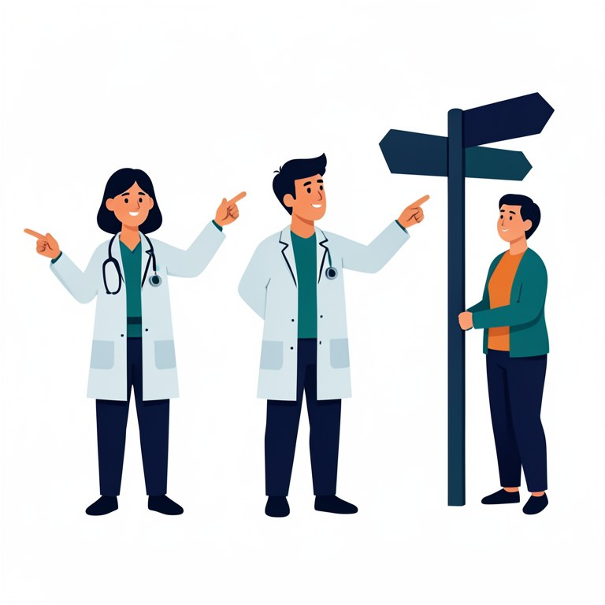

Illustrative image, generated with FLUX.2 [klein] 4B

## Deep ensembles — strengths and pitfalls

Use it when

- You can afford **N trainings** (five is the usual number).
- You want an uncertainty that **grows away from the data**: 0.016 inside the sine’s range, 0.47 outside.
- Bonus: the average of the members is usually more accurate and better calibrated than any single member.

Watch out

- N times the training, the storage and the prediction time.
- Members that share the same **blind spot** agree on it: on 35 % darker X-rays our five ResNet18s disagreed **less** than on clean ones (0.024 vs 0.059).
- Still no guarantee: “large spread” needs a threshold, chosen on data.

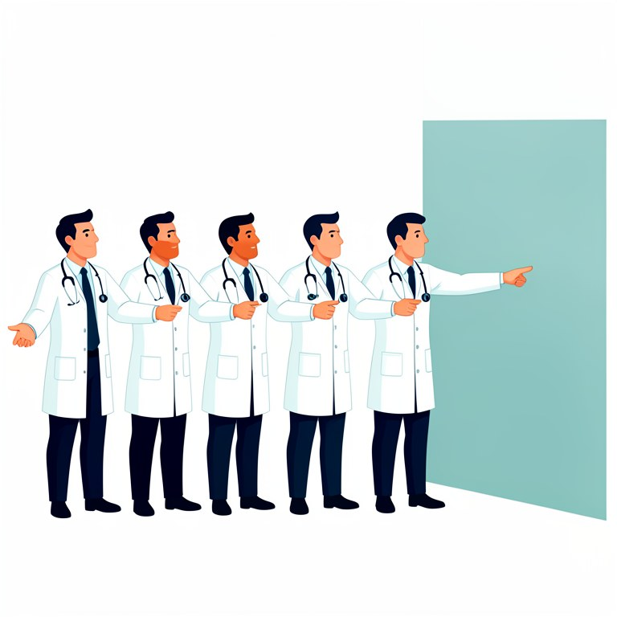

Illustrative image, generated with FLUX.2 [klein] 4B

## Conformal prediction, briefly

**any model**

and a calibration set

→

**score**

how unusual is the true label

→

**threshold**

the $1 - \alpha$ quantile of the scores

→

**prediction set**

every label below the threshold

- **Guarantee:** the true label is in the set in at least $1 - \alpha$ of the cases — for any model, with a finite calibration set, no distributional assumption beyond exchangeable data.
- For an X-ray the set is {pneumonia}, {normal} or **{both}** — and “both” is the model saying “I don’t know”.

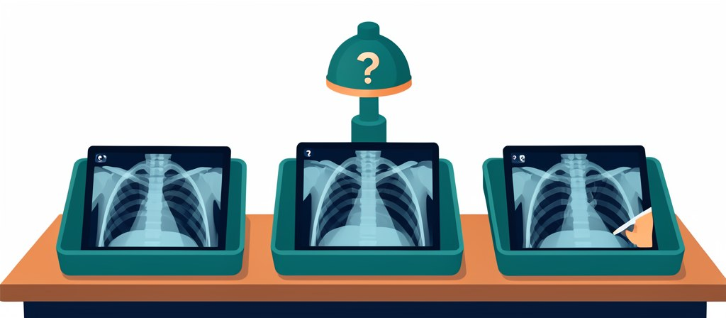

Illustrative image, generated with FLUX.2 [klein] 4B

## Conformal prediction on our X-rays

[figure not shown]

Calibrated on data like the patients — half of the test X-rays — the promise holds: **0.90**, and 11 % of the sets say “both”. Calibrated on the validation split, or applied to darker images, it breaks — and the darker images get **fewer** “I don’t know” sets, not more.

## Conformal prediction — strengths and pitfalls

Use it when

- You need a **stated error rate**: “the true label is in the set in 90 % of cases” — on our X-rays 0.90.
- Any model, any score; no retraining — one quantile on a calibration set.
- The set size is a usable signal: {both} goes to a clinician.

Watch out

- The guarantee needs **exchangeable** data: calibrated on the validation split it gave 0.73, on darker images 0.66.
- It holds **on average** over patients — not for each subgroup, not for each patient.
- With two classes the sets are coarse: one label, both, or empty.

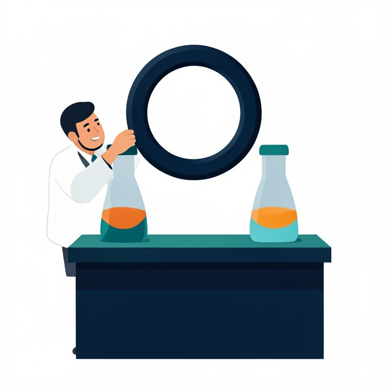

Illustrative image, generated with FLUX.2 [klein] 4B

## From uncertainty to an OOD flag

**score**

ensemble disagreement, MC-Dropout variance, set size

→

**threshold**

chosen on held-out in-distribution data

→

**decision**

above it: flag the input, route it to a clinician

Far enough from the training data, the model should say “I don’t know” instead of a confident wrong answer.

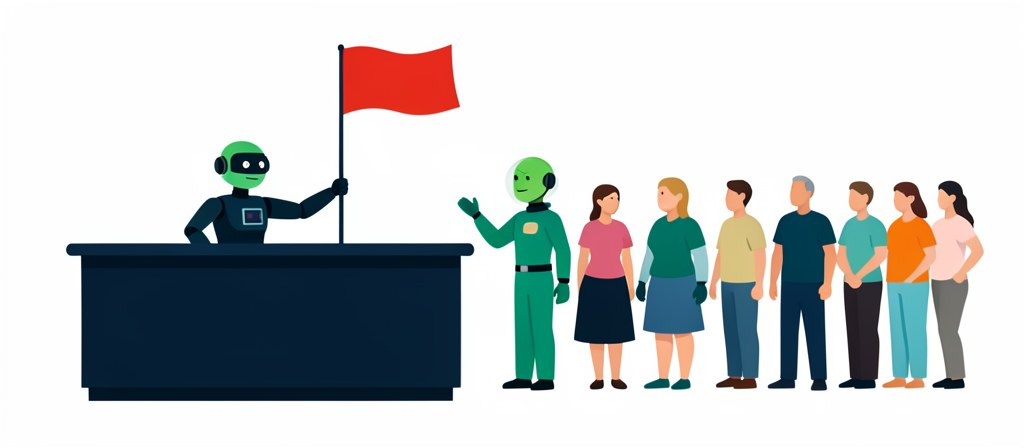

Illustrative image, generated with FLUX.2 [klein] 4B

## Does the model know it is lost?

[figure not shown]

The more wrong the model is, the **surer** it gets: on 35 % darker X-rays it errs on 36 % of them and flags 4 %. Five models agree even more — they all learned the same thing, and all fail the same way.

## Refer the uncertain ones

[figure not shown]

- Sort the X-rays by confidence; the least confident go to a radiologist.
- Clean: **0.856 → 0.928** with 20 % referred, **0.959** with 30 %.
- Darker: still below the clean model with no referral at all, even after referring 30 %.

## 4 · After deployment

> The day a model ships is the day its test set starts to age.

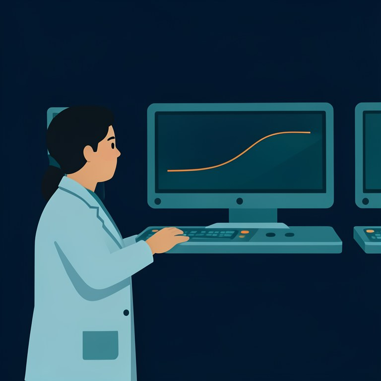

Illustrative image, generated with FLUX.2 [klein] 4B

## Drift that actually came

- Spring 2020, the same sepsis model in **24 US hospitals**.
- Three weeks before and three weeks after each health system’s first COVID-19 case: the share of inpatients raising a sepsis alert each day went from **9 % to 21 %** — while the census **fell by 35 %**.
- Michigan Medicine **paused the alerts** in April 2020 after the nurses reported over-alerting.

Nothing in the model changed. What did?

Wong et al. (2021), *JAMA Netw Open* 4:e2135286, [doi:10.1001/jamanetworkopen.2021.35286](https://doi.org/10.1001/jamanetworkopen.2021.35286) · Finlayson et al. (2021), *The clinician and dataset shift in artificial intelligence*, *NEJM* 385:283, [doi:10.1056/NEJMc2104626](https://doi.org/10.1056/NEJMc2104626)

## Monitoring in production

Data drift

the inputs change — a new scanner, a new population, a new referral pathway; visible **at once**, from the inputs and the predictions alone

Performance drift

accuracy or calibration degrade — visible only **when the ground truth arrives**: a lab result, a biopsy, a follow-up

**alarm**

a drift measure crosses a threshold

→

**look**

what changed, and is it the model’s problem?

→

**act**

recalibrate, retrain — or route to a clinician

Tooling, for example [Evidently AI](https://docs.evidentlyai.com/introduction); the lab computes the same measures by hand.

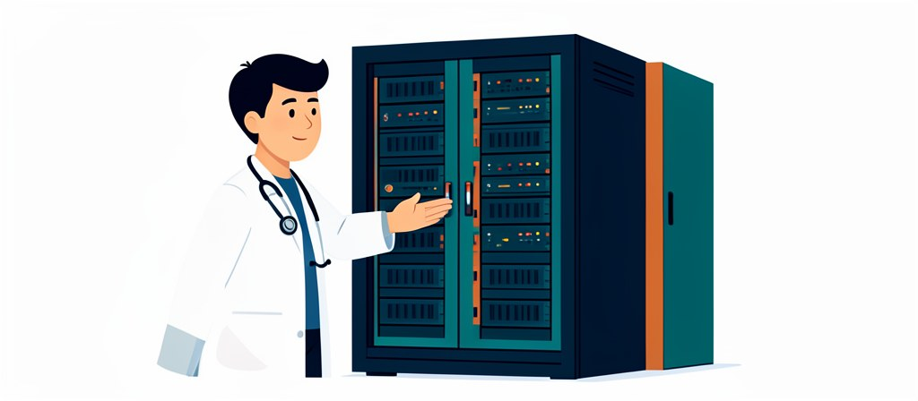

Illustrative image, generated with FLUX.2 [klein] 4B

## Two ways to measure drift

**Population stability index** — how much the distribution moved:

$$\mathrm{PSI} = \sum_{i=1}^{k} (q_i - p_i)\,\ln\frac{q_i}{p_i}$$

$p_i$, $q_i$ are the shares of the reference and the current batch in bin $i$ of the predicted probability. Rule of thumb: below 0.10 stable, 0.10–0.25 watch, above 0.25 alert.

**Kolmogorov–Smirnov test** — is there any difference at all:

$$D = \max_t \,\big|\,F_{\mathrm{ref}}(t) - F_{\mathrm{cur}}(t)\,\big|$$

$F$ are the empirical distribution functions of the two samples; the test turns $D$ into a p-value. Small p: the batch is unlikely to come from the reference distribution.

PSI measures **how large** the change is; the p-value measures **how sure** we are that there is one. With big batches a tiny change is significant; with small batches a large one may not be.

K-S — Kolmogorov–Smirnov

## A monitoring dashboard

[figure not shown]

## A new hospital on the dashboard

[figure not shown]

## PSI — strengths and pitfalls

Use it when

- You want **how much** the distribution moved, on a scale with agreed levels (0.10, 0.25).
- No labels needed: it runs on the predictions (or any input feature) from the first day.
- Easy to compute, easy to plot week by week.

Watch out

- The levels are a **convention** from credit scoring, not a law.
- It depends on the **bins**: five bins for 60 patients here; ten would mostly measure noise.
- Empty bins need a floor (here 10⁻⁴), or PSI is infinite.
- It sees a shift of the distribution, **not** whether the model is still right — the label-shift weeks raised it while the accuracy held.

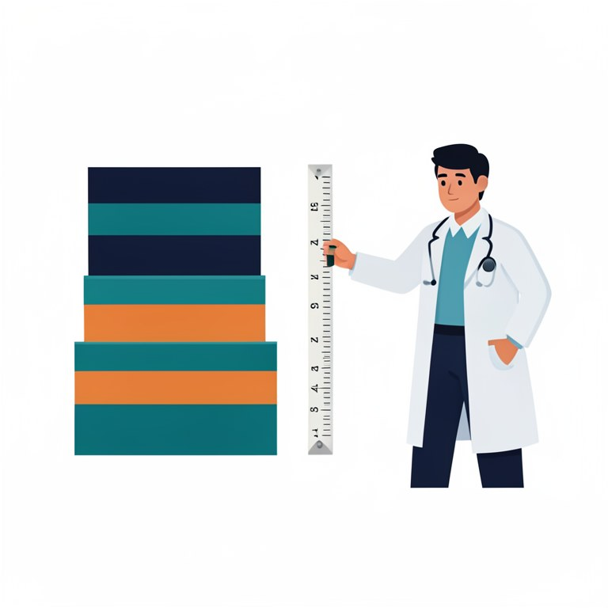

Illustrative image, generated with FLUX.2 [klein] 4B

## The K-S test — strengths and pitfalls

Use it when

- You want to know **whether** the batch differs at all, with a stated error rate.
- No bins, no tuning: the whole empirical distribution is compared.
- One line in SciPy (`ks_2samp`).

Watch out

- A p-value is **evidence, not size**: a big batch makes a tiny shift significant, a small one hides a large shift.
- Ten weeks, ten tests: at p < 0.05, one false alarm in twenty quiet weeks is expected.
- On one number at a time (a score or a feature); it says nothing about which patients changed.

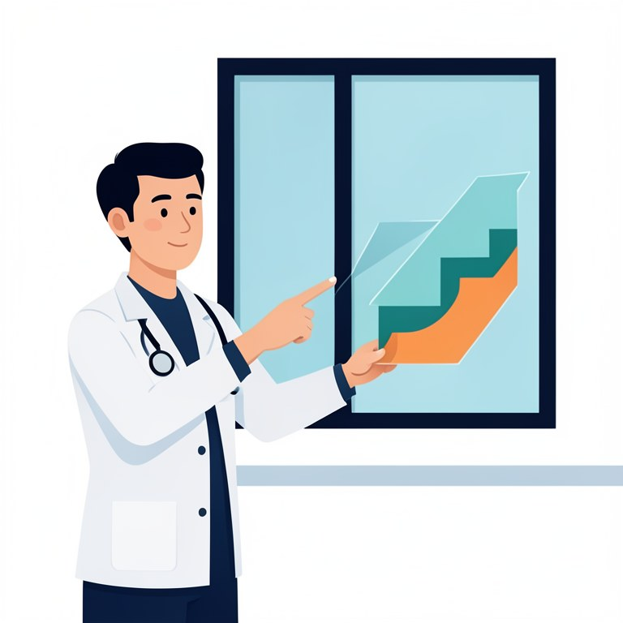

Illustrative image, generated with FLUX.2 [klein] 4B

## 5 · What to take home

> A test-set accuracy is a promise about one data set. Keep checking whether you are still on it.

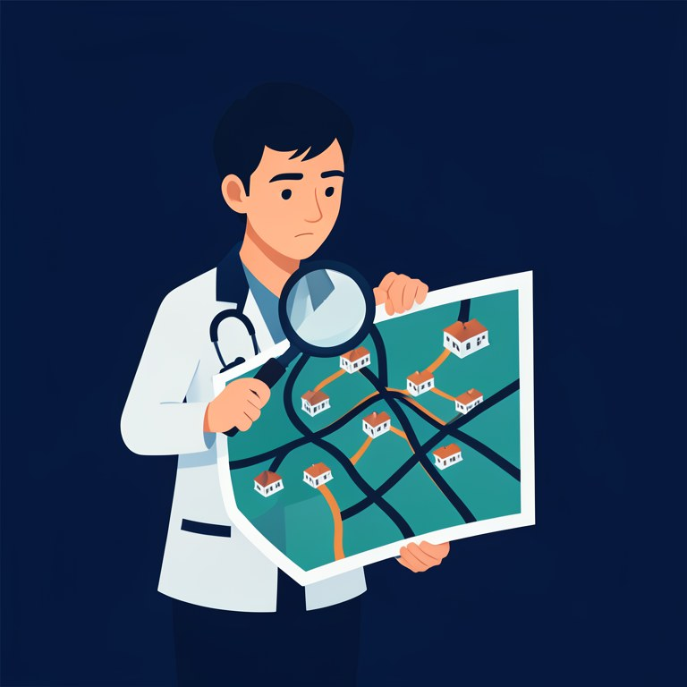

Illustrative image, generated with FLUX.2 [klein] 4B

## Takeaways

1. **Test where it will break.** Hold out whole hospitals, and all images of a patient together. Elsewhere our Heart Disease model kept most of its ranking and lost its decisions; a darker X-ray sent the ResNet18 to “pneumonia” for all — augment, then re-check the clean data.
2. **A score is not a probability until you check it.** Reliability diagram, ECE, Brier; fix the spread with $T$ and the level with $b$, on data from the population you deploy in.
3. **Small test sets lie in both directions.** Repeat the split before you believe a change of ECE.
4. **Uncertainty has to be tested too.** On darker X-rays our model was more sure, the ensemble more unanimous, the conformal sets smaller.
5. **Watch the inputs and the predictions after deployment.** Empty fields, PSI, K-S — they see drift before the accuracy does.

## Quick check

1. The pneumonia CNN never saw a hospital ID. How did it learn the hospital?
2. Swiss AUC 0.72, Swiss accuracy 0.58: how can both hold, and what would you re-fit?
3. Why does a 35 % darker image hurt our ResNet18 more than strong noise?
4. Temperature scaling changed the probabilities. Why could it not change the accuracy?
5. ECE got worse on 2 splits of 20. What does one ECE on 76 patients tell you?
6. Conformal sets promised 90 % and covered 66 % of darker X-rays. What broke?
7. On darker X-rays: 36 % wrong, 4 % flagged. Why did the confidence not warn you?
8. PSI 0.06, K-S p 0.81, but one patient in five has an empty field. Call someone?

## The lab and the sources

### The lab — three parts

1. **Corruption robustness** — the ResNet18 under four corruptions at five severities, then retrained with jitter; does its confidence notice?
2. **Calibration** — ECE, Brier and temperature scaling by hand, twenty splits, the three other hospitals and a hospital left out.
3. **Monitoring** — ten weekly batches, PSI and the K-S test; a new hospital and its empty fields.

[Lab page](https://github.com/tomasvicar/AUI-public/tree/master/labs/robustness) · [`pneumonia.py`](https://github.com/tomasvicar/AUI-public/blob/master/lectures/robustness/code/pneumonia.py) · [`heart.py`](https://github.com/tomasvicar/AUI-public/blob/master/lectures/robustness/code/heart.py) — every number of the lecture

### Reading

- Zech et al. (2018), *PLOS Medicine* — a different hospital;
- Finlayson et al. (2021), *NEJM* 385:283 — dataset shift for clinicians;
- Guo et al. (2017), [arXiv:1706.04599](https://arxiv.org/abs/1706.04599) — calibration;
- Lakshminarayanan et al. (2017), [arXiv:1612.01474](https://arxiv.org/abs/1612.01474) — deep ensembles;
- Angelopoulos, Bates (2021), [arXiv:2107.07511](https://arxiv.org/abs/2107.07511) — conformal prediction;
- MedMNIST-C, [arXiv:2406.17536](https://arxiv.org/abs/2406.17536) — corruption benchmark;
- Goodfellow et al. (2015), [arXiv:1412.6572](https://arxiv.org/abs/1412.6572) — FGSM; Madry et al. (2018), [arXiv:1706.06083](https://arxiv.org/abs/1706.06083) — PGD;
- Ovadia et al. (2019), [arXiv:1906.02530](https://arxiv.org/abs/1906.02530) — uncertainty under shift.